# WETO ddRAD pipeline - R - 1) vcf statistics

Jayna Bergman

2024-08-16

Version of R used: 4.3.3

### Project

WETO DUs population genomics pipeline

### Overview

#### **Goal(s):**

This script will assess vcf statistics for missing data and depth of coverage.

#### **Details about files and pipeline:**

1. File information

> 2. Input files and their contents

> > ind_depth is the coverage of depth per individual. The columns in this file are:
> > 1. INDV: Names of the individuals
> > 2. N_SITES:
> > 3. MEAN_DEPTH: Depth of coverage per individual

> > ind_missing is the frequency of missingness per individual. The columns in this file are:
> > 1. INDV: Names of the individuals
> > 2. N_DATA: Number of SNPs in the vcf file
> > 3. N_GENOTYPES_FILTERED: Number of genotypes filtered out
> > 4. N_MISS: Number of sites with missing data per individual
> > 5. F_MISS: Frequency of missing sites per individual

### Setting up the R environment

#### Working directory:

```r
setwd("C:/Users/jayna/OneDrive/Desktop/School/Lee_Yaw_Lab/Masters_Thesis/DRAC/Plate_1")
```

#### Libraries:

```r
# load libraries
library(dplyr)
library(lubridate)
library(knitr)
library(ggplot2)
library(gridExtra)
library(tidyverse)
library(stringr)
library(ggrepel)
library(vcfR)
```

#### Function definitions: NA

### Data and Analysis

#### Load and explore the data

Load the data:

```r
### load data

ind_depth <- read.delim("./vcftools_stats_WETO_plate1/LD_HWE_MI20_MAC5.idepth")

ind_missing <- read.delim("./vcftools_stats_WETO_plate1/LD_HWE_MI20_MAC5.imiss")

mean_depth <- read.delim("./vcftools_stats_WETO_plate1/LD_HWE_MI20_MAC5.ldepth.mean")

site_missing <- read.delim("./vcftools_stats_WETO_plate1/LD_HWE_MI20_MAC5.lmiss")
```

Get summary information:  
The length of ind_depth and ind_missing should be equal to the number of individuals included.  
The length of mean_depth and site_missing should be equal to the number of SNPs.

```r
summary(ind_depth)
```

```
##      INDV              N_SITES        MEAN_DEPTH
##  Length:47          Min.   :12942   Min.   : 3.262
##  Class :character   1st Qu.:15986   1st Qu.: 7.362
##  Mode  :character   Median :16281   Median : 8.424
##                     Mean   :16108   Mean   : 8.755
##                     3rd Qu.:16476   3rd Qu.:10.026
##                     Max.   :16754   Max.   :16.257
```

```r
summary(ind_missing)
```

```
##      INDV               N_DATA      N_GENOTYPES_FILTERED     N_MISS
##  Length:47          Min.   :17340   Min.   :0            Min.   : 586
##  Class :character   1st Qu.:17340   1st Qu.:0            1st Qu.: 864
##  Mode  :character   Median :17340   Median :0            Median :1059
##                     Mean   :17340   Mean   :0            Mean   :1232
##                     3rd Qu.:17340   3rd Qu.:0            3rd Qu.:1354
##                     Max.   :17340   Max.   :0            Max.   :4398
##      F_MISS
##  Min.   :0.03379
##  1st Qu.:0.04983
##  Median :0.06107
##  Mean   :0.07105
##  3rd Qu.:0.07806
##  Max.   :0.25363
```

```r
summary(mean_depth)
```

```
##     CHROM                POS              MEAN_DEPTH        VAR_DEPTH
##  Length:17340       Min.   :     2361   Min.   :  1.415   Min.   :    0.35
##  Class :character   1st Qu.: 66084903   1st Qu.:  4.674   1st Qu.:    4.47
##  Mode  :character   Median :184944101   Median :  6.022   Median :    7.50
##                     Mean   :262499021   Mean   :  8.711   Mean   :   32.81
##                     3rd Qu.:448751110   3rd Qu.: 10.144   3rd Qu.:   24.77
##                     Max.   :804511105   Max.   :207.809   Max.   :31904.40
```

```r
summary(site_missing)
```

```
##      CHR                 POS                N_DATA   N_GENOTYPE_FILTERED
##  Length:17340       Min.   :     2361   Min.   :94   Min.   :0
##  Class :character   1st Qu.: 66084903   1st Qu.:94   1st Qu.:0
##  Mode  :character   Median :184944101   Median :94   Median :0
##                     Mean   :262499021   Mean   :94   Mean   :0
##                     3rd Qu.:448751110   3rd Qu.:94   3rd Qu.:0
##                     Max.   :804511105   Max.   :94   Max.   :0
##      N_MISS           F_MISS
##  Min.   : 0.000   Min.   :0.00000
##  1st Qu.: 2.000   1st Qu.:0.02128
##  Median : 6.000   Median :0.06383
##  Mean   : 6.679   Mean   :0.07105
##  3rd Qu.:12.000   3rd Qu.:0.12766
##  Max.   :18.000   Max.   :0.19149
```

Quick look at the first few rows of data.

```r
head(ind_depth)
```

```
##                              INDV N_SITES MEAN_DEPTH
## 1 AQ9-LOST1_DNA1.WETO_REF.PP.sort   16165    8.20841
## 2     AS-1_DNA80.WETO_REF.PP.sort   16476   10.32370
## 3     BO-5A_DNA1.WETO_REF.PP.sort   16531   11.36620
## 4     DR-1_DNA80.WETO_REF.PP.sort   16342   10.96100
## 5    FF-26_DNA80.WETO_REF.PP.sort   16216    8.08683
## 6      HU1_DNA80.WETO_REF.PP.sort   16450   11.73680
```

```r
head(ind_missing)
```

```
##                              INDV N_DATA N_GENOTYPES_FILTERED N_MISS    F_MISS
## 1 AQ9-LOST1_DNA1.WETO_REF.PP.sort  17340                    0   1175 0.0677624
## 2     AS-1_DNA80.WETO_REF.PP.sort  17340                    0    864 0.0498270
## 3     BO-5A_DNA1.WETO_REF.PP.sort  17340                    0    809 0.0466551
## 4     DR-1_DNA80.WETO_REF.PP.sort  17340                    0    998 0.0575548
## 5    FF-26_DNA80.WETO_REF.PP.sort  17340                    0   1124 0.0648212
## 6      HU1_DNA80.WETO_REF.PP.sort  17340                    0    890 0.0513264
```

```r
head(mean_depth)
```

```
##                                     CHROM    POS MEAN_DEPTH VAR_DEPTH
## 1 Scaffold_1__2_contigs__length_508792519 265940    4.12766   4.02683
## 2 Scaffold_1__2_contigs__length_508792519 387943   18.12770  53.02680
## 3 Scaffold_1__2_contigs__length_508792519 531855    6.23077   6.12955
## 4 Scaffold_1__2_contigs__length_508792519 614296   16.06520  49.70680
## 5 Scaffold_1__2_contigs__length_508792519 623478   22.55320  78.16560
## 6 Scaffold_1__2_contigs__length_508792519 623509    5.10526   4.04267
```

```r
head(site_missing)
```

```
##                                       CHR    POS N_DATA N_GENOTYPE_FILTERED
## 1 Scaffold_1__2_contigs__length_508792519 265940     94                   0
## 2 Scaffold_1__2_contigs__length_508792519 387943     94                   0
## 3 Scaffold_1__2_contigs__length_508792519 531855     94                   0
## 4 Scaffold_1__2_contigs__length_508792519 614296     94                   0
## 5 Scaffold_1__2_contigs__length_508792519 623478     94                   0
## 6 Scaffold_1__2_contigs__length_508792519 623509     94                   0
##   N_MISS    F_MISS
## 1      0 0.0000000
## 2      0 0.0000000
## 3     16 0.1702130
## 4      2 0.0212766
## 5      0 0.0000000
## 6     18 0.1914890
```

#### Step 1 of analysis: Assess vcf statistics

Make graphs to visualize the distribution of the coverage of depth and the missingness per individual and per site.

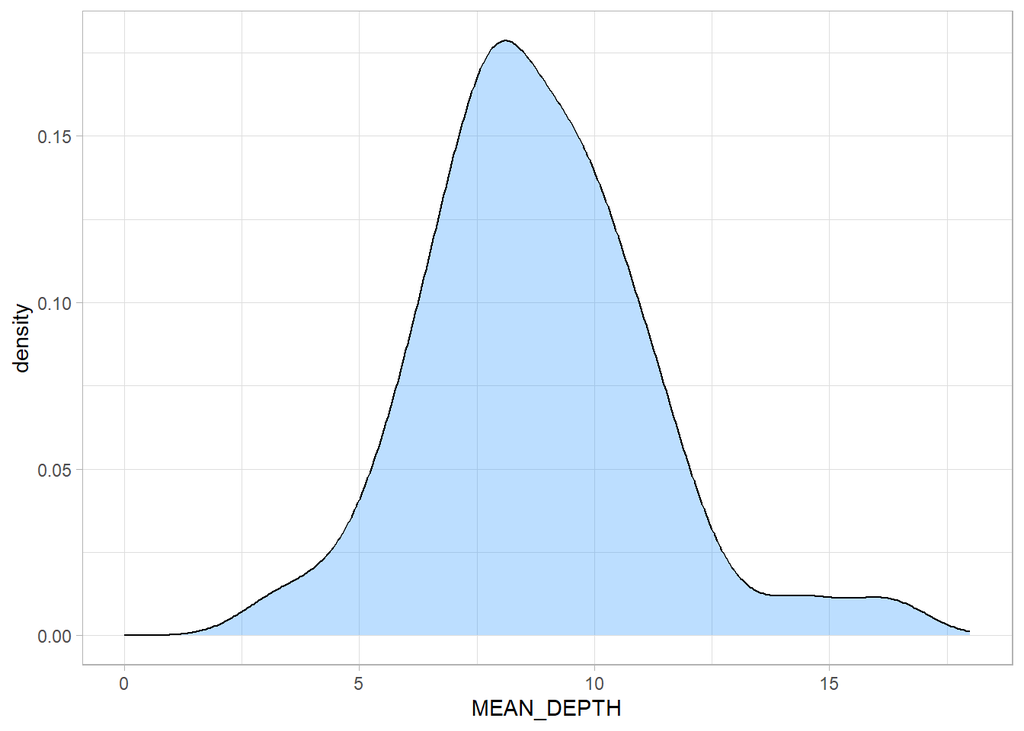

```r
#Individual depth of coverage

ind_depth_plot <- ggplot(ind_depth, aes(MEAN_DEPTH)) +
  scale_x_continuous(limits=c(0,18)) +
  geom_density(fill="dodgerblue1", color = "black", alpha = 0.3) +
  theme_light()

ind_depth_plot
```

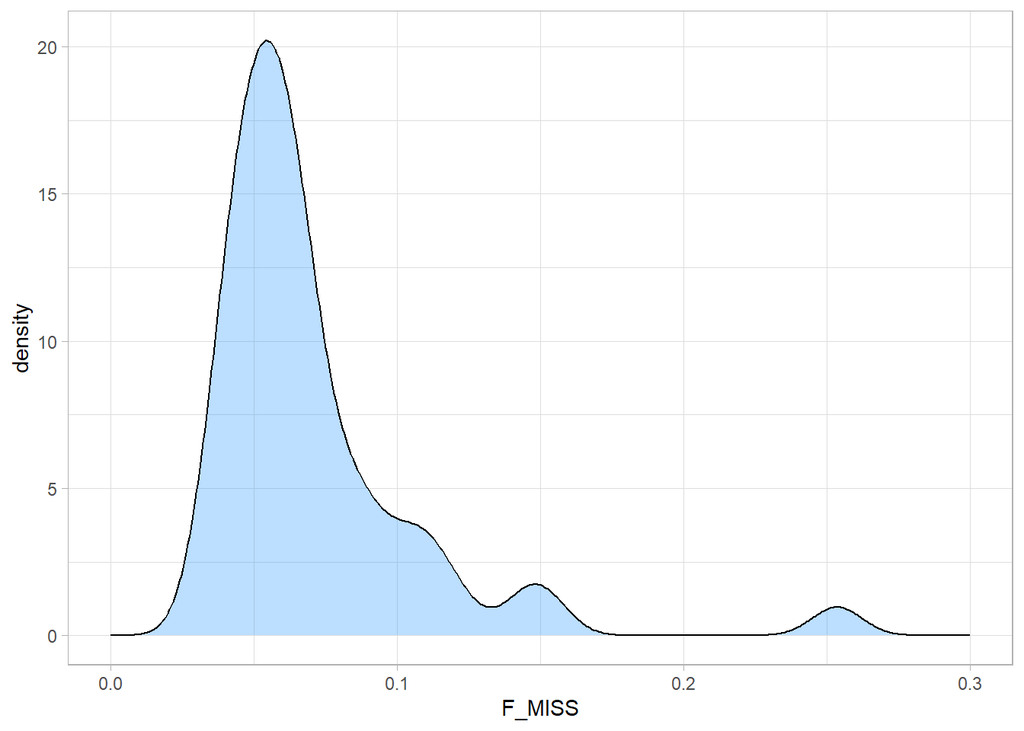

```r
ind_missing_plot <- ggplot(ind_missing, aes(F_MISS)) +
  scale_x_continuous(limits=c(0,0.3)) +
  geom_density(fill="dodgerblue1", color="black", alpha = 0.3) +
  theme_light()

ind_missing_plot
```

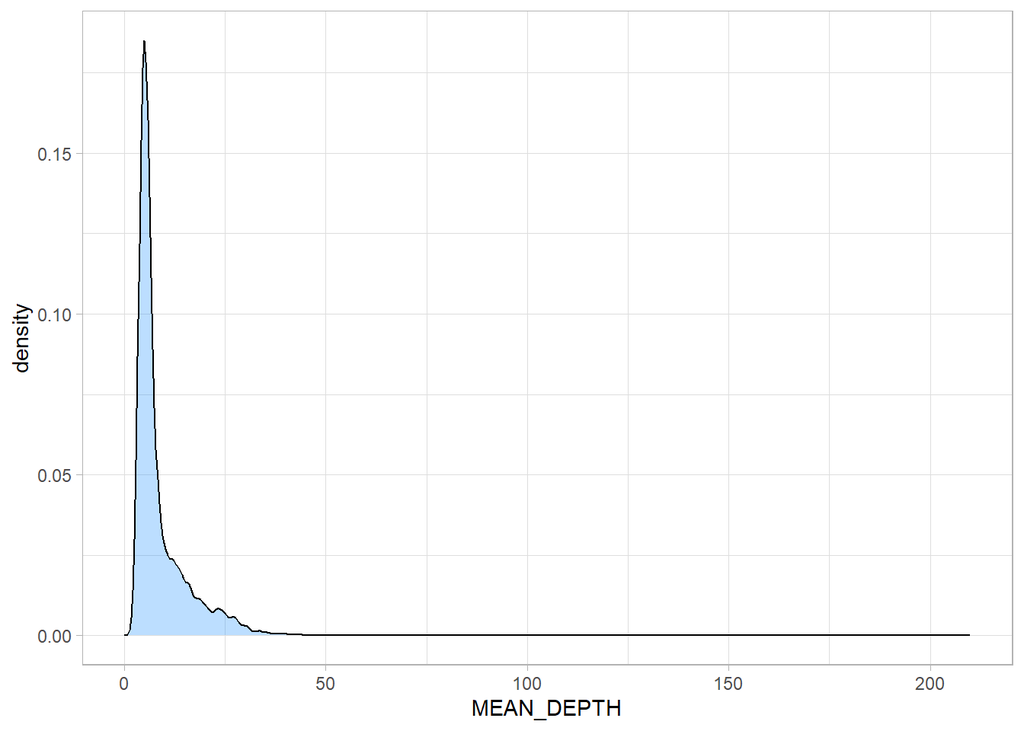

```r
site_depth_plot <- ggplot(mean_depth, aes(MEAN_DEPTH)) +
  scale_x_continuous(limits=c(0,210)) +
  geom_density(fill="dodgerblue1", color="black", alpha=0.3) +
  theme_light()

site_depth_plot
```

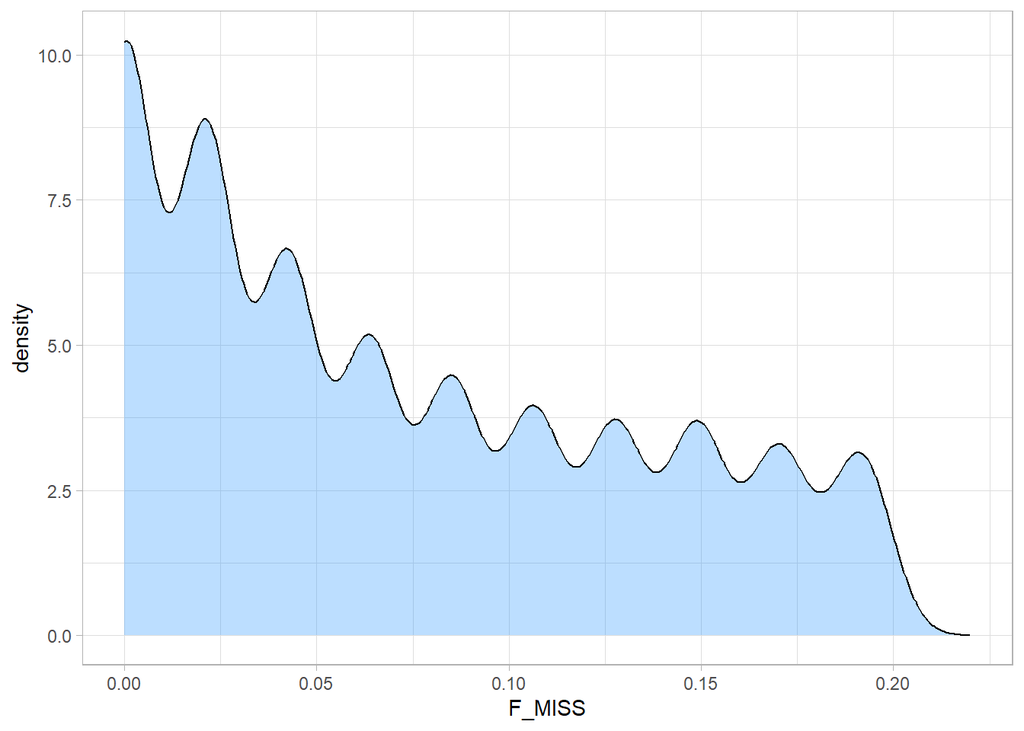

```r
site_missing_plot <- ggplot(site_missing, aes(F_MISS)) +
  scale_x_continuous(limits=c(0,0.22)) +
  geom_density(fill="dodgerblue1", color="black", alpha=0.3) +
  theme_light()

site_missing_plot
```

**Interpretation**  
The depth of coverage per individual seems consistent across each individual (no outliers).  
One individual is missing more than the others (0.25 is the max). Will plot per individual to see which sample it is.  
Very few sites have more than 50X coverage.

#### Step 1 of analysis: looking deeper into the data

Plot the missingness per individual to determine which individual has the maximum missingness.

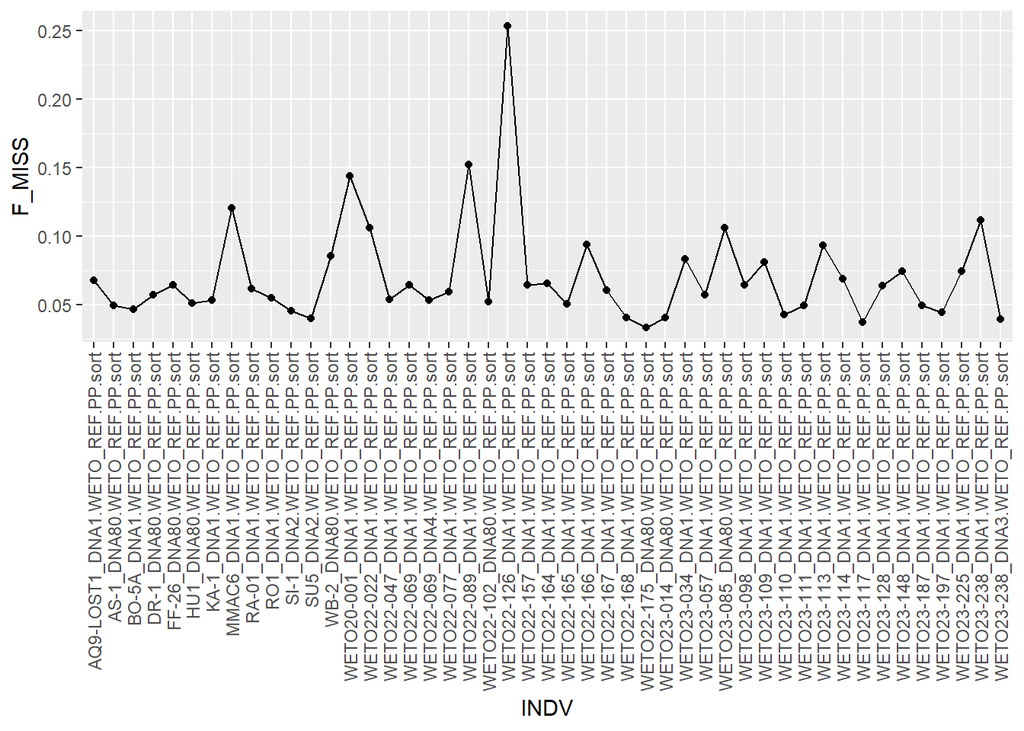

```r
ind_missing_plot2 <- ggplot(ind_missing, aes(x=INDV, y=F_MISS, group=1)) +
  geom_point() +
  geom_line() +
  theme(axis.text.x = element_text(angle=90, hjust=1, vjust=0.5))


ind_missing_plot2
```

**Interpretation**  
The individual with the most missingness is WETO22-126.  
**Question:** WETO23-238_DNA1 has a higher missingness than DNA3. How does this impact the purpose of the positive control?

### Conclusions and final notes

The next script in this pipeline will generate visualizations for STRUCTURE (WETO ddRAD pipeline - R - 2) STRUCTURE)